# Практична робота № 8

# Тема. Жадібні алгоритми. Наближене розв’язання екстремальних задач

# Мета: набути практичних навичок застосування деяких жадібних алгоритмів для розв’язання екстремальних задач.

# Вхідні дані

**Заданий зважений граф: [(1,2,3), (1,3,5), (1,4,7), (2,3,6), (2,4,8), (3,4,9)]**

# Результат роботи алгоритму

- Найкоротший маршрут: (1, 4 )
- Його довжина: 7

# Візуалізація графа

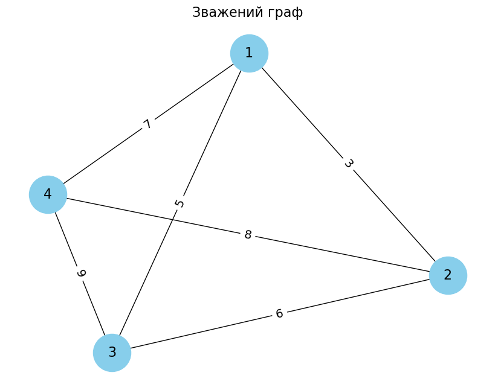

```python
import networkx as nx
import matplotlib.pyplot as plt

# Заданий зважений граф
edges = [(1,2,3), (1,3,5), (1,4,7), (2,3,6), (2,4,8), (3,4,9)]

# Створення графа
G = nx.Graph()
G.add_weighted_edges_from(edges)

# Позиції для вузлів
pos = nx.spring_layout(G, seed=42)

# Візуалізація графа
plt.figure(figsize=(8,6))
nx.draw(G, pos, with_labels=True, node_color='skyblue', node_size=2000, font_size=16)
nx.draw_networkx_edge_labels(G, pos, edge_labels={(u, v): w for u, v, w in edges}, font_size=14)
plt.title("Зважений граф", fontsize=16)
plt.show()
```

# Контрольні питання

# 1. Що таке жадібний алгоритм?

- Жадібний алгоритм — це алгоритм, який на кожному кроці приймає локально оптимальне рішення, сподіваючись, що воно призведе до глобально оптимального результату.

# 2. Які головні принципи роботи жадібних алгоритмів?

- Основні принципи:
- Жадібний вибір: на кожному кроці вибирається найкращий з доступних варіантів (з точки зору деякого критерію).
- Локальна оптимальність: рішення в кожній точці є найкращим на даний момент.
- Незмінність підзадачі: після прийняття рішення, залишок задачі має бути подібним до початкової, тобто можна застосовувати той самий підхід.

# 3. Яка головна відмінність між жадібними алгоритмами та динамічним програмуванням?

- Критерій Жадібні алгоритми Динамічне програмування
- Підхід Локально оптимальні вибори Повний перебір усіх підзадач
- Гарантія оптимальності Не завжди Завжди (для правильно сформульованих задач)
- Повторне використання рішень Немає Є (мемоізація/таблиці)
- Складність реалізації Проста Складніша

# 4. Приклади задач, які можна розв’язати за допомогою жадібних алгоритмів:

- Задача про монети (мінімальна кількість монет для суми) – тільки для деяких валютних систем.
- Задача Кангуру і дерево (макс. покриття вузлів).
- Задача про рюкзак (лише дробова версія — fractional knapsack).
- Алгоритм Крускала або Прима для пошуку мінімального остовного дерева (MST).
- Алгоритм Дейкстри — знаходження найкоротших шляхів.
- Планування розкладу: задача про інтервали (interval scheduling).

# 5. Які можуть бути обмеження у використанні жадібних алгоритмів для розв'язання екстремальних задач?

- Немає гарантії глобальної оптимальності: жадібне рішення не завжди веде до найкращого результату.
- Залежність від задачі: працює лише в задачах, де дотримується властивість жадібної оптимальності.
- Не можна відкотитись назад: немає повернення до попередніх рішень, навіть якщо вони були помилковими.
- Часто потребує доказу правильності, що складно для складних задач.

# 6. Чому жадібні алгоритми часто використовуються для наближеного розв’язання екстремальних задач?

- Швидкість: Жадібні алгоритми працюють значно швидше, ніж повні перебори або динамічне програмування.
- Простота реалізації: менше коду, менше ресурсів.
- Дають хороші наближення: для багатьох NP-складних задач жадібні стратегії дають розв’язки, близькі до оптимальних (наприклад,
- задачі про покриття множини або рюкзак).
- Часто використовуються в евристиках, жадібних апроксимаційних алгоритмах та онлайн-алгоритмах.